# Práctica 1

Melissa Martínez, Isabel Herrera, Alondra Dominguez.

2025-02-03

**Introducción**  
La tecnologia de rna-seq es un tipo de secuenciacion de nueva generacion que permite cuantificar la presencia de RNAm de una muestra, principalmente usado para mapear cambios y secuencias en el genoma, dentro de sus funciones permite determinar la expresion de genes, splicing alternativo, ARN no codificante, y el estudio del transcriptoma de una celula unica.  
Esta tecnica ha ganado popularidad debido a que puede ser usada para el diagnostico de enfermedades que se consideran raras, debido a la capacidad de esta tecnologia de analizar todos los genes expresados, a comparacion de las pasadas que solo analizaban regiones especificas dentro del genoma.

**Objetivos**

- Entender el proceso que realiza el software rna-seq al momento de mapear un genoma con los transcritos.
- Realizar el análisis en R para observar la abundancia de los transcritos.

**Evidencia fotografica.**

## <sup><sub>**Gen A**</sub></sup>

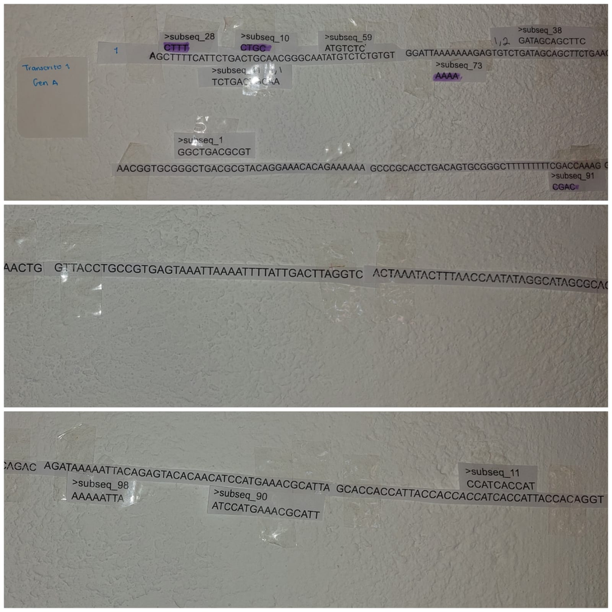

**Figura 1.** En esta imagen se observa al gen A con su mapeo correspondiente. En esta foto se observa que hay subseq marcados de color morado, esto indica que están presentes en varios genes. Se eligió de manera ambigua en que gen se colocaban.

**Gen B**

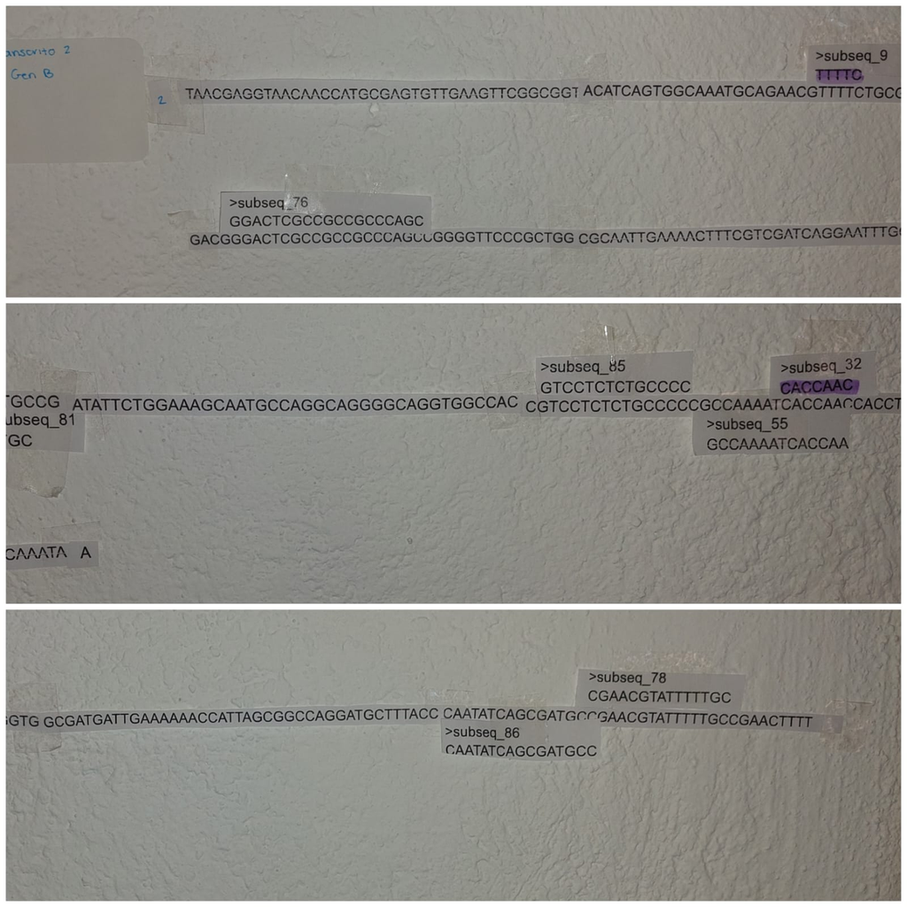

**Figura 2.** Mapeo del gen B.

**Gen C**

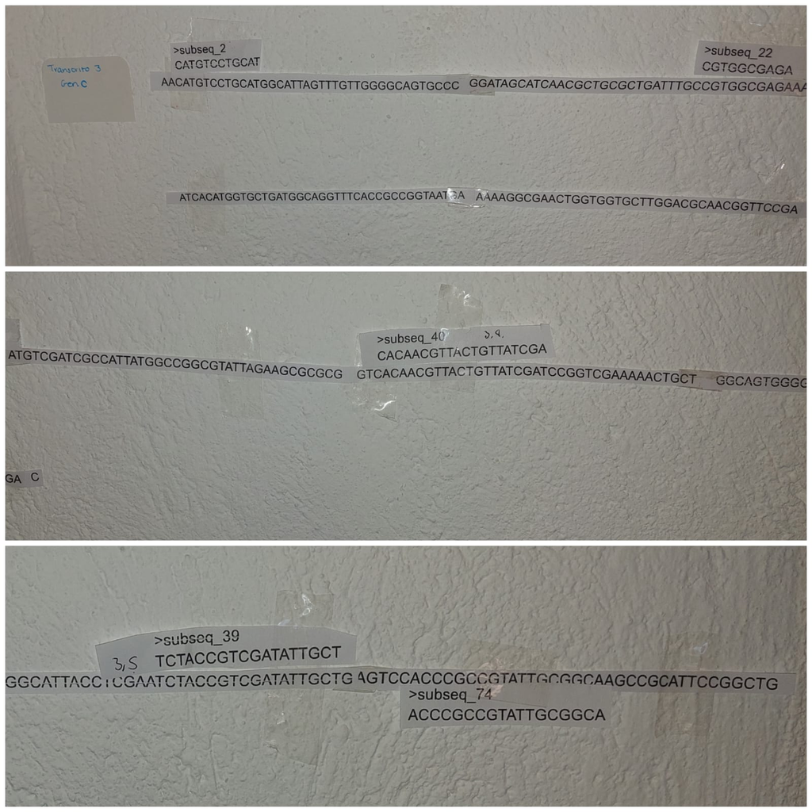

**Figura 3.** Mapeo del gen C

**Gen D**

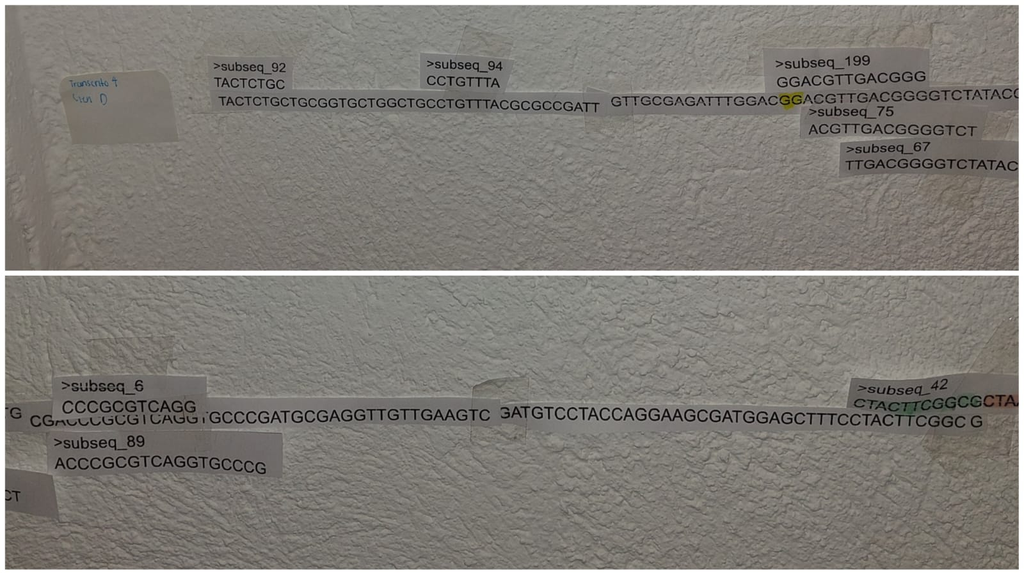

**Figura 4.** Mapeo gen D.

**Gen E y Gen F**

[figure not shown]

**Figura 5.** Aquí se observa las secuencias de los genes E y F, los cuales tienen sus correspondientes secuencias mapeadas.

**Gen 7.**

[figure not shown]

**Figura 6**.En está imagen se observá el gen 7. Transcrito G con el mapeo de secuencias.

**Discusión**

¿Cuál es el impacto del tamaño del read para el tanto en eficiencia como precisión del mapeo? Si el read tiene un tamaño mayor es más fácil ubicarlo en la parte específica del genoma, además, esto disminuye la probabilidad de que la secuencia sea ambigua y pueda estar en diferentes partes del mismo gen y distribuida a lo largo de varios genes. Si el read tiene un tamaño menor, la secuencia puede repetirse a lo largo del genoma y si no se tiene el genoma anotado ni se conoce en que parte debe de estar presente, es difícil identificar a que parte especifica corresponde dando como resultado mapeos ambiguos y poner la secuencia en regiones donde hay secuencias similares o repetidas.

¿Cuál es el impacto de los tamaños de los genes para la evaluación de la expresión génica?  
Un gen de mayor tamaño puede tener más transcritos dentro, las secuencias de mayor tamaño son más faciles de insertar y pueden generar más lecturas comparada a un gen pequeño, que tiene menos lecturas las cuales tambien son de menor tamaño y que algunas pueden ser ambiguas. Un problema de los transcritos de mayor tamaño es que estos tienden a tener más regiones repetidas que afecten al momento de mapear transcritos de menor tamaño.

Existen mapeos ambiguos, cómo pueden darse este tipo de mapeos.  
Los mapeos ambiguos ocurren cuando una secuencia, en su mayoría corta, aparece más veces a lo largo de la secuencia de un solo gen, en nuestro caso solo registramos la presencia de una solo subsecuencia en el mapeo, estos mapeos ambiguos pueden dar lecturas incorrectas si no se conoce en que parte del genoma está presente esa secuencia, esto afecta la precisión de la lectura. En nuestro caso en el mapeo a mano, las secuencias ambiguas fueron colocadas de manera arbitraria en cualquier parte del gen.

Durante esta práctica se hizo el mapeo físico, este fue complementado con el mapeo realizado por los ciclos for donde se buscó cada transcrito/subsecuencia, se realizó el conteo de cuantas veces en el gen.

```r
library(Biostrings)

genes <- readDNAStringSet("../Datos/genes.FASTA")
print(genes)
```

```
## DNAStringSet object of length 10:
##      width seq                                              names
##  [1]   320 AGCTTTTCATTCTGACTGCAACG...GGCTTTTTTTTTCGACCAAAGG GEN_A
##  [2]   320 TAACGAGGTAACAACCATGCGAG...GATCAGGAATTTGCCCAAATAA GEN_B
##  [3]   320 AACATGTCCTGCATGGCATTAGT...GCTTGGACGCAACGGTTCCGAC GEN_C
##  [4]   160 TACTCTGCTGCGGTGCTGGCTGC...ATGGAGCTTTCCTACTTCGGCG GEN_D
##  [5]   239 CTAAAGTTCTTCACCCCCGCACC...GTCTTTGCAGCGATGTCACGCG GEN_E
##  [6]   160 CCCGTATTTCCGTGGTGCTGATT...AGCCGCTGGCAGTGACGGAACG GEN_F
##  [7]   480 GCTGGCCATTATCTCGGTGGTAG...ACCCGGTCATTGTTGACTGCAC GEN_G
##  [8]   560 TTCCAGCCAGGCAGTGGCGGATC...AAGGCCCGTGATGAAGGAAAAG GEN_H
##  [9]   240 TTTTGCGCTATGTTGGCAATATT...TCATGGAAGTTAGGAGTCTGAC GEN_I
## [10]   320 ATGGTTAAAGTTTATGCCCCGGC...CCTGTTCGGTGGTCGCGGCGCT GEN_J
```

```r
subsecuencias <- readDNAStringSet("../Datos/subsecuencias.FASTA")
print(subsecuencias)
```

```
## DNAStringSet object of length 200:
##       width seq                                             names
##   [1]    11 GGCTGACGCGT                                     subseq_1
##   [2]    12 CATGTCCTGCAT                                    subseq_2
##   [3]    18 TTGCTGATCTGCTACGTA                              subseq_3
##   [4]    19 AGTGGCGATGACCCTGGAA                             subseq_4
##   [5]    20 AGGAAACACAGAAAAAAGCC                            subseq_5
##   ...   ... ...
## [196]    13 TTAACCAATATAG                                   subseq_196
## [197]    20 GGCAGTGCCCGGATAGCATC                            subseq_197
## [198]    20 CGTATTAGAAGCGCGCGGTC                            subseq_198
## [199]    13 GGACGTTGACGGG                                   subseq_199
## [200]     4 GTGG                                            subseq_200
```

```r
abundancia_subsecuencias_totales <- data.frame(
  Gen = character(),
  Total_subsecuencias_por_gen = integer()
)

for (nombre_gen in names(genes)) {
  contador_subsecuencias_totales <- 0
  for (nombre_subsecuencia in names(subsecuencias)) {
    conteo <- countPattern(subsecuencias[[nombre_subsecuencia]], genes[[nombre_gen]])
    contador_subsecuencias_totales <- contador_subsecuencias_totales + conteo
  }

  abundancia_subsecuencias_totales <- rbind(
    abundancia_subsecuencias_totales,
    data.frame(Gen = nombre_gen, Total_subsecuencias_por_gen = contador_subsecuencias_totales)
  )
}

print(abundancia_subsecuencias_totales)
```

```
##      Gen Total_subsecuencias_por_gen
## 1  GEN_A                          49
## 2  GEN_B                          50
## 3  GEN_C                          43
## 4  GEN_D                          33
## 5  GEN_E                          27
## 6  GEN_F                          22
## 7  GEN_G                          58
## 8  GEN_H                          88
## 9  GEN_I                          39
## 10 GEN_J                          35
```

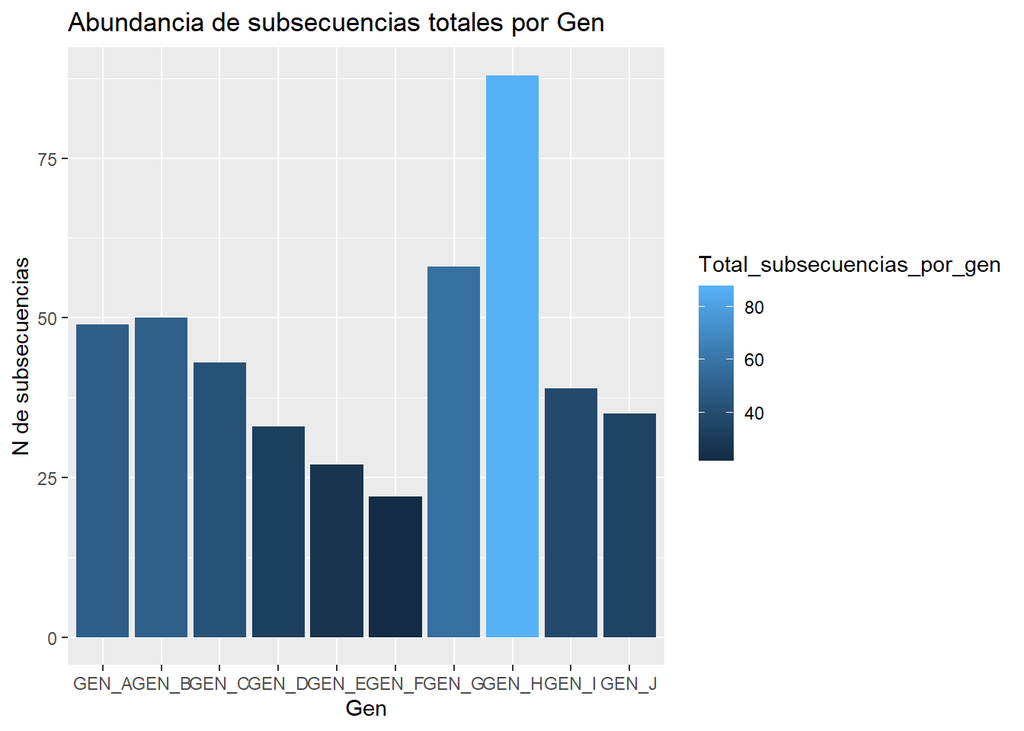

```r
library(ggplot2)

G_AT<- ggplot( abundancia_subsecuencias_totales, aes (x= Gen, y=Total_subsecuencias_por_gen , fill = Total_subsecuencias_por_gen)) + geom_bar(stat = "identity" ) + labs (title = "Abundancia de subsecuencias totales por Gen ", x= "Gen", y= "N de subsecuencias")

print (G_AT)
```

```r
abundancia_subsecuencias_unicas <- data.frame(
  Gen = character(),
  Subsecuencias_unicas_por_gen = integer()
)


for (nombre_gen in names(genes)) {
  contador_subsecuencias_unicas <- 0
  for (nombre_subsecuencia in names(subsecuencias)) {
    conteo <- countPattern(subsecuencias[[nombre_subsecuencia]], genes[[nombre_gen]])
    if (conteo > 0) {
      contador_subsecuencias_unicas <- contador_subsecuencias_unicas + 1
    }
  }

  abundancia_subsecuencias_unicas <- rbind(
    abundancia_subsecuencias_unicas,
    data.frame(Gen = nombre_gen, Subsecuencias_unicas_por_gen = contador_subsecuencias_unicas)
  )
}

print(abundancia_subsecuencias_unicas)
```

```
##      Gen Subsecuencias_unicas_por_gen
## 1  GEN_A                           29
## 2  GEN_B                           33
## 3  GEN_C                           28
## 4  GEN_D                           29
## 5  GEN_E                           23
## 6  GEN_F                           20
## 7  GEN_G                           42
## 8  GEN_H                           50
## 9  GEN_I                           29
## 10 GEN_J                           30
```

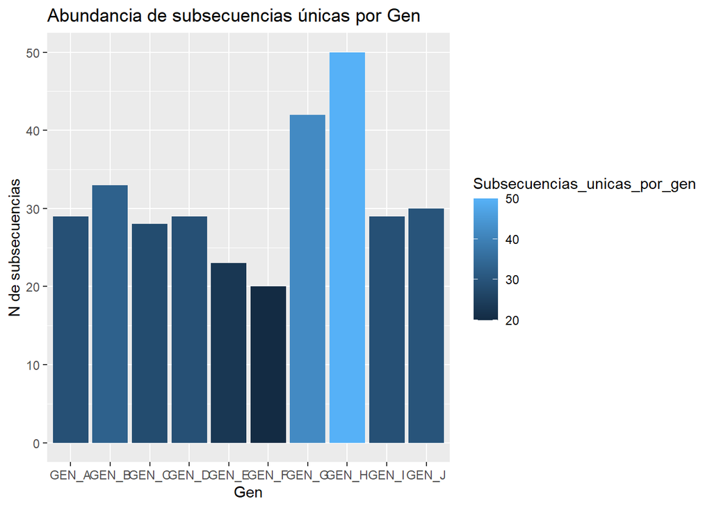

```r
library(ggplot2)

G_AU<- ggplot( abundancia_subsecuencias_unicas, aes (x= Gen, y= Subsecuencias_unicas_por_gen , fill = Subsecuencias_unicas_por_gen)) +
  geom_bar(stat = "identity" ) +
  labs (title = "Abundancia de subsecuencias únicas por Gen ",
         x= "Gen", y= "N de subsecuencias")

print (G_AU)
```

```r
resultado_subsecuencias_genes <- data.frame(
  Subsecuencia = character(),
  Genes = character()
)

for (nombre_subsecuencia in names(subsecuencias)) {
  genes_con_subsecuencia <- c()
  for (nombre_gen in names(genes)) {
    conteo <- countPattern(subsecuencias[[nombre_subsecuencia]], genes[[nombre_gen]])
    if (conteo > 0) {
      genes_con_subsecuencia <- c(genes_con_subsecuencia, nombre_gen)
    }
  }

  resultado_subsecuencias_genes <- rbind(
    resultado_subsecuencias_genes,
    data.frame(
      Subsecuencia = nombre_subsecuencia,
      Genes = paste(genes_con_subsecuencia, collapse = ", ")
    )
  )
}


print(resultado_subsecuencias_genes)
```

```
##     Subsecuencia                                                         Genes
## 1      subseq_1                                                          GEN_A
## 2      subseq_2                                                          GEN_C
## 3      subseq_3                                                          GEN_I
## 4      subseq_4                                                          GEN_J
## 5      subseq_5                                                          GEN_A
## 6      subseq_6                                                          GEN_D
## 7      subseq_7                                                          GEN_J
## 8      subseq_8
## 9      subseq_9                                                   GEN_A, GEN_B
## 10    subseq_10  GEN_A, GEN_B, GEN_C, GEN_D, GEN_F, GEN_G, GEN_H, GEN_I, GEN_J
## 11    subseq_11                                                          GEN_A
## 12    subseq_12                                                          GEN_E
## 13    subseq_13                                                          GEN_J
## 14    subseq_14                                                          GEN_I
```

[output cut: 186 more lines]